# Almond Yield Anomaly: Function & Analysis

Pat Byrne, Hannah Garcia, and Yani Pohl

4/7/2021

```r
# Install packages
library(tidyverse)
library(lubridate)
library(patchwork)
library(kableExtra)
```

### Read in climate data and run yield_anomaly function

```r
# Read in data frame & convert date column (D) to a date
clim.df <- read.table('clim_edited.txt',header = TRUE) %>%
  mutate(
    D = as.Date(D)
  )

# Read in yield_anomaly.R function
source("yield_anomaly.R")

# Run the function with clim.df using years 2000-2002
test.func <- yield_anomaly(input.dataframe = clim.df, years.calc = c(2000,2001,2002))
test.func[1,]
```

```
## [1] 2000.000000    9.599988
```

```r
test.func[2,]
```

```
## [1] 2001.000  159.512
```

```r
test.func[3,]
```

```
## [1] 2002.0000000    0.2450914
```

### Summarize the results

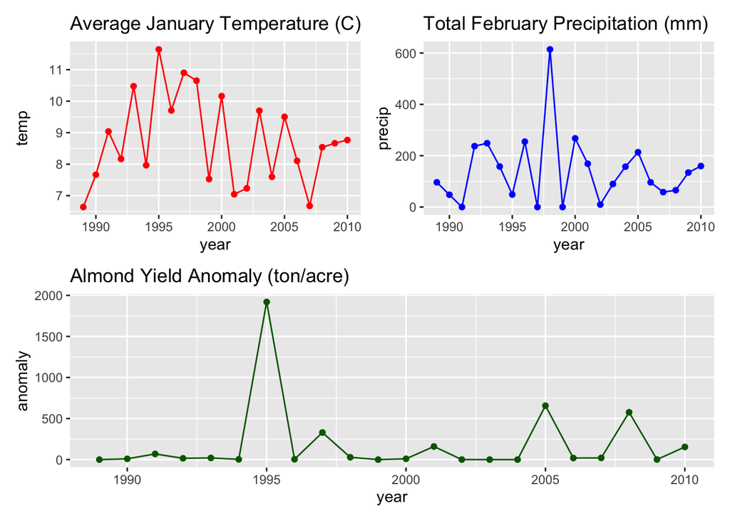

**Figure. 1** Almond yield anomaly (ton/acre), average minimum January temperature (C), and total February precipitation (mm) for years 1989 to 2010. The almond yield anomaly is the difference from the 1983-2003 average yield.

```r
# Calculate almond yield anomaly for 1988-2010

almond.func <- yield_anomaly(input.dataframe = clim.df, years.calc = c(1989:2010))

# make a df of the almond yield anomaly for each year
almond.df = tibble(year = almond.func[,1], anomaly= almond.func[,2])

# Create data frames to summarize mean temp for January and mean precip for February for each year

temp.df <- clim.df %>%
  filter(month == 1) %>%
  group_by(year) %>%
  summarise(temp = mean(tmin_c))

precip.df <- clim.df %>%
  filter(month == 2) %>%
  group_by(year) %>%
  summarise(precip = sum(precip))

# Graph anomaly, temp, and precip using 'patchwork'

anomaly.plot <- ggplot(almond.df, aes(x = year, y = anomaly)) +
  geom_line(color = "darkgreen") +
  geom_point(color = "darkgreen") +
  labs(title = "Almond Yield Anomaly (ton/acre)")

temp.plot <- ggplot(data = temp.df, aes(x = year, y = temp)) +
  geom_line(color = "red") +
  geom_point(color = "red") +
  labs(title = "Average January Temperature (C)")

precip.plot <- ggplot(precip.df, aes(x = year, y = precip)) +
  geom_line(color = "blue") +
  geom_point(color = "blue") +
  labs(title = "Total February Precipitation (mm)")

(temp.plot|precip.plot)/anomaly.plot
```

```r
# Merge dataframes

almond_temp <- inner_join(almond.df, temp.df, by="year")
total <- inner_join(almond_temp, precip.df, by="year")

# create table
table  <- total %>%
  kable(col.names = c("Year",
               "Yield Anomaly (ton/acre)",
               "Average Minimum Temperature (C)",
               "Total Precipitation (mm)")) %>%
  kable_styling(bootstrap_options = "bordered",
                full_width = F,
                position = "left")


table
```

| Year | Yield Anomaly (ton/acre) | Average Minimum Temperature (C) | Total Precipitation (mm) |
| --- | --- | --- | --- |
| 1989 | -0.3552237 | 6.639247 | 96.370 |
| 1990 | 9.2906757 | 7.664803 | 47.891 |
| 1991 | 68.9130633 | 9.038996 | 0.000 |
| 1992 | 15.4280698 | 8.167401 | 237.164 |
| 1993 | 20.2083803 | 10.475538 | 248.615 |
| 1994 | 2.4820009 | 7.966362 | 157.845 |
| 1995 | 1919.9811511 | 11.644875 | 48.716 |
| 1996 | 3.5818399 | 9.705735 | 254.764 |
| 1997 | 329.6938750 | 10.903064 | 0.000 |
| 1998 | 27.8636956 | 10.651129 | 614.250 |
| 1999 | -0.1436364 | 7.528656 | 0.000 |
| 2000 | 9.5999883 | 10.162527 | 267.701 |
| 2001 | 159.5119587 | 7.045143 | 168.755 |
| 2002 | 0.2450914 | 7.233459 | 9.631 |
| 2003 | -0.2585997 | 9.698100 | 89.916 |
| 2004 | -0.2367722 | 7.598638 | 157.226 |
| 2005 | 656.3724121 | 9.503423 | 213.614 |
| 2006 | 18.6324135 | 8.105054 | 96.266 |
| 2007 | 20.2007396 | 6.676147 | 58.166 |
| 2008 | 576.2821943 | 8.538037 | 65.532 |
| 2009 | 0.7367438 | 8.665278 | 134.366 |
| 2010 | 153.7655092 | 8.767070 | 159.766 |

**Table 1.** Almond yield anomaly (ton/acre), average minimum January temperature (C), and total February precipitation (mm) for years 1989 to 2010. The almond yield anomaly is the difference from the 1983-2003 average yield."

```r
# calculate average temperature & precip of all years
# mean(total$temp) = 8.7
# mean(total$precip) = 142.1161
```

### Write one paragraph summarizing your findings

There were 3 years that had noticeably higher almond years than the 1983-2003 average: 1995, 2005, and 2008. The average minimum January temperature for these years were 11.6 C, 9.5 C, and 8.5 C, respectively. The average minimum January temperature for all years was approximately 8.7 C; years 1995 and 2005 had higher than average temperatures, which could potentially be contributing to their higher almond yields. Regarding precipitation, years 1995 and 2008 had fairly low totals. In 2005, precipitation totals were 213 mm, greater than the average total precipitation of years 1989-2010, which averaged approximately 142 mm.

Overall, there is not a clear trend of how the average January minimum temperature and total February precipitation affects almond yield anomalies. There may be more information that is needed to draw definite conclusions. For example, there could have been agricultural pests that decimated crops or issues with pollinator activity. However, our function, ‘yield_anomaly.R’ can be used by almond farmers to predict their almond yield based on minimum temperature and total rainfall parameters.